# Session 3: Spatial Interpolation and Smoothing in R

Queensland rainfall and SA2 disease rates | Hands-on spatial epidemiology

## Learning objectives

By the end of this tutorial, you should be able to prepare spatial data in a projected coordinate system; explain and apply nearest-neighbour, inverse distance weighting (IDW), and ordinary kriging interpolation; assess interpolation with leave-one-out cross-validation; explain and map global empirical Bayes and neighbourhood-pooled disease rates; and demonstrate how bandwidth changes a kernel density estimate (KDE).

**Three questions to keep separate:** Interpolation asks *what value might occur at an unmeasured location?* Disease-rate smoothing asks *how can unstable rates across areas be stabilised?* KDE asks *where are point events concentrated?* These are related spatial techniques but not interchangeable.

## Download the tutorial datasets

Download the following datasets before running the practical exercises:

- **Queensland daily rainfall data, 2024 (ZIP)** — compressed daily rainfall records used in Part A. Download and extract the ZIP file before running the exercises.
- **Queensland boundary shapefile (ZIP)** — download and extract the ZIP file before running Part A.
- **Queensland SA2 spatial epidemiology dataset (GeoPackage)** — population, disease cases, and crude rates used in Parts B and C.

Download all three datasets before running the practical exercises. Extract the Queensland boundary shapefile ZIP and place its components (.shp, .shx, .dbf, and .prj) in the same folder as index.html. The rainfall ZIP file can be placed in the same folder without manually extracting it, as the R code below will automatically unzip it. Place the SA2 GeoPackage in the same folder. For GitHub Pages, each download link must point to an accessible hosted file. embed-resources: true embeds page assets such as figures, but does not embed these downloadable datasets.

**Data interpretation:** Some annual rainfall totals include a small number of SILO-filled days, even after the 95% observation-based completeness filter. The SA2 dataset contains aggregated case counts, not individual case locations.

## Part A: Spatial interpolation of rainfall

### 1. Load The Required Packages

```r
# Load packages for data manipulation, mapping,
# raster analysis, and spatial interpolation.
library(tidyverse)
library(sf)
library(terra)
library(gstat)
```

### 2. Import The Queensland Rainfall Data

```r
# Download and extract the Queensland rainfall dataset.

# Define the ZIP and CSV filenames.
zip_file <- "QLD_SILO_Daily_Rainfall_2024_raw.zip"
csv_file <- "QLD_SILO_Daily_Rainfall_2024_raw.csv"

# Download the ZIP file from GitHub if it is not available.
if (!file.exists(zip_file) && !file.exists(csv_file)) {
  download.file(
    "https://raw.githubusercontent.com/BehzadKiani/spatial-epidemiology-r-tutorial/main/session-3/QLD_SILO_Daily_Rainfall_2024_raw.zip",
    destfile = zip_file,
    mode = "wb"
  )
}

# Extract the CSV file if it does not already exist.
if (!file.exists(csv_file)) {
  unzip(
    zip_file,
    files = csv_file,
    exdir = "."
  )
}

# Read daily rainfall data for Queensland weather stations
# during 2024.
rainfall_daily <- read_csv(
  csv_file,
  show_col_types = FALSE
)

# Examine the structure of the dataset.
glimpse(rainfall_daily)
```

```
Rows: 319,518
Columns: 12
$ station_code    <chr> "039000", "039000", "039000", "039000", "039000", "039…
$ station_name    <chr> "Abercorn", "Abercorn", "Abercorn", "Abercorn", "Aberc…
$ year            <dbl> 2024, 2024, 2024, 2024, 2024, 2024, 2024, 2024, 2024, …
$ month           <dbl> 1, 1, 1, 1, 1, 1, 1, 1, 1, 1, 1, 1, 1, 1, 1, 1, 1, 1, …
$ day             <dbl> 1, 2, 3, 4, 5, 6, 7, 8, 9, 10, 11, 12, 13, 14, 15, 16,…
$ date            <date> 2024-01-01, 2024-01-02, 2024-01-03, 2024-01-04, 2024-…
$ elev_m          <chr> "200.0 m", "200.0 m", "200.0 m", "200.0 m", "200.0 m",…
$ extracted       <date> 2026-10-07, 2026-10-07, 2026-10-07, 2026-10-07, 2026-…
$ latitude        <dbl> -25.1333, -25.1333, -25.1333, -25.1333, -25.1333, -25.…
$ longitude       <dbl> 151.1292, 151.1292, 151.1292, 151.1292, 151.1292, 151.…
$ rainfall        <dbl> 0.0, 47.6, 1.2, 0.0, 0.0, 0.0, 2.0, 0.0, 0.0, 3.2, 1.4…
$ rainfall_source <dbl> 0, 0, 0, 0, 0, 0, 0, 0, 0, 0, 0, 0, 0, 15, 15, 0, 0, 0…
```

### 3. Explore The Rainfall Data

```r
# Count the total number of daily rainfall records.
nrow(rainfall_daily)
```

```
[1] 319518
```

```r
# Count the number of unique rainfall stations.
n_distinct(
  rainfall_daily$station_code
)
```

```
[1] 873
```

```r
# Check the date range.
range(
  rainfall_daily$date
)
```

```
[1] "2024-01-01" "2024-12-31"
```

```r
# Look at the first few records.
head(
  rainfall_daily
)
```

| station_code | station_name | year | month | day | date | elev_m | extracted | latitude | longitude | rainfall | rainfall_source |
| --- | --- | --- | --- | --- | --- | --- | --- | --- | --- | --- | --- |
| 039000 | Abercorn | 2024 | 1 | 1 | 2024-01-01 | 200.0 m | 2026-10-07 | -25.1333 | 151.1292 | 0.0 | 0 |
| 039000 | Abercorn | 2024 | 1 | 2 | 2024-01-02 | 200.0 m | 2026-10-07 | -25.1333 | 151.1292 | 47.6 | 0 |
| 039000 | Abercorn | 2024 | 1 | 3 | 2024-01-03 | 200.0 m | 2026-10-07 | -25.1333 | 151.1292 | 1.2 | 0 |
| 039000 | Abercorn | 2024 | 1 | 4 | 2024-01-04 | 200.0 m | 2026-10-07 | -25.1333 | 151.1292 | 0.0 | 0 |
| 039000 | Abercorn | 2024 | 1 | 5 | 2024-01-05 | 200.0 m | 2026-10-07 | -25.1333 | 151.1292 | 0.0 | 0 |
| 039000 | Abercorn | 2024 | 1 | 6 | 2024-01-06 | 200.0 m | 2026-10-07 | -25.1333 | 151.1292 | 0.0 | 0 |

```r
# CHECK THE NUMBER OF DAYS AVAILABLE FOR EACH STATION

# 2024 was a leap year and therefore contained 366 days.
days_in_year <- 366


# Count the number of daily records for each station.
station_days <- rainfall_daily |>
  count(
    station_code,
    station_name,
    name = "DAYS"
  )


# Summarise the number of records per station.
summary(
  station_days$DAYS
)
```

```
   Min. 1st Qu.  Median    Mean 3rd Qu.    Max.
    366     366     366     366     366     366
```

```r
# Identify any stations that do not have 366 daily records.
station_days |>
  filter(
    DAYS != days_in_year
  )
```

| station_code | station_name | DAYS |
| --- | --- | --- |

### 4. Examine Rainfall Data Quality

```r
# SILO provides a source code for each daily rainfall value.
#
# In this dataset:
#
# 0  = direct Bureau of Meteorology observation
#
# 15 = rainfall based on an accumulated station observation
#      that SILO redistributed across the relevant days
#
# 25 = rainfall estimated using spatial interpolation
#
# We will treat source codes 0 and 15 as
# observation-based rainfall.


# Count records belonging to each rainfall source.
table(
  rainfall_daily$rainfall_source,
  useNA = "ifany"
)
```

```
     0     15     25
188582   4421 126515
```

```r
# Create a variable identifying observation-based rainfall.
rainfall_daily <- rainfall_daily |>
  mutate(
    OBSERVATION_BASED =
      rainfall_source %in% c(0, 15)
  )


# Check the number of observation-based and
# interpolated daily records.
table(
  rainfall_daily$OBSERVATION_BASED
)
```

```
 FALSE   TRUE
126515 193003
```

### 5. Calculate Station Completeness

```r
# Summarise the daily data to produce one record
# for each rainfall station.
station_summary <- rainfall_daily |>

  group_by(
    station_code,
    station_name,
    latitude,
    longitude
  ) |>

  summarise(

    # Number of observation-based days.
    DAYS_OBSERVED = sum(
      OBSERVATION_BASED,
      na.rm = TRUE
    ),

    # Number of days interpolated by SILO.
    DAYS_INTERPOLATED = sum(
      rainfall_source == 25,
      na.rm = TRUE
    ),

    # Percentage of the year supported by
    # observation-based rainfall.
    COMPLETENESS = 100 *
      DAYS_OBSERVED /
      days_in_year,

    # Total annual rainfall using the complete
    # daily SILO rainfall series.
    ANNUAL_RAINFALL = sum(
      rainfall,
      na.rm = TRUE
    ),

    .groups = "drop"
  )


# Examine the station-level dataset.
glimpse(
  station_summary
)
```

```
Rows: 873
Columns: 8
$ station_code      <chr> "027000", "027015", "027031", "027038", "027042", "0…
$ station_name      <chr> "Aurukun Shire Council", "Moreton Telegraph Station"…
$ latitude          <dbl> -13.3539, -12.4536, -10.8969, -16.4231, -12.6267, -1…
$ longitude         <dbl> 141.7208, 142.6389, 142.3844, 143.1456, 141.8836, 14…
$ DAYS_OBSERVED     <int> 0, 366, 366, 366, 366, 366, 362, 358, 362, 366, 361,…
$ DAYS_INTERPOLATED <int> 366, 0, 0, 0, 0, 0, 4, 8, 4, 0, 5, 366, 7, 60, 366, …
$ COMPLETENESS      <dbl> 0.00000, 100.00000, 100.00000, 100.00000, 100.00000,…
$ ANNUAL_RAINFALL   <dbl> 2088.4, 1455.9, 2380.5, 1447.1, 1845.6, 1669.5, 1981…
```

```r
# EXAMINE STATION COMPLETENESS

# Summarise completeness across all stations.
summary(
  station_summary$COMPLETENESS
)
```

```
   Min. 1st Qu.  Median    Mean 3rd Qu.    Max.
   0.00    0.00   94.26   60.40  100.00  100.00
```

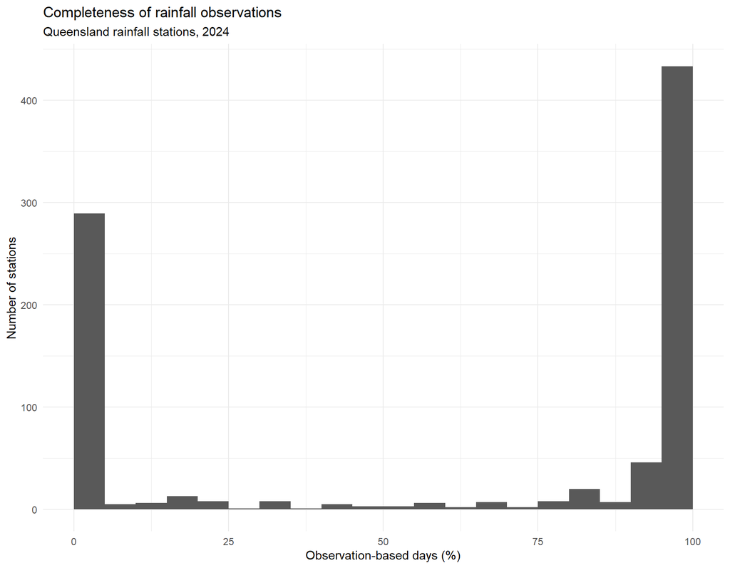

```r
# Plot the distribution of station completeness.
ggplot(
  station_summary,
  aes(
    x = COMPLETENESS
  )
) +

  geom_histogram(
    binwidth = 5,
    boundary = 0
  ) +

  labs(
    title = "Completeness of rainfall observations",
    subtitle = "Queensland rainfall stations, 2024",
    x = "Observation-based days (%)",
    y = "Number of stations"
  ) +

  theme_minimal()
```

```r
# RETAIN STATIONS WITH AT LEAST 95% COMPLETENESS

# Stations must have observation-based rainfall
# for at least 95% of the year.
rainfall_stations <- station_summary |>
  filter(
    COMPLETENESS >= 95
  )


# Count the retained stations.
nrow(
  rainfall_stations
)
```

```
[1] 433
```

```r
# CHECK THE FINAL COMPLETENESS OF RETAINED STATIONS

summary(
  rainfall_stations$COMPLETENESS
)
```

```
   Min. 1st Qu.  Median    Mean 3rd Qu.    Max.
  95.63   99.73  100.00   99.63  100.00  100.00
```

```r
# Check the number of SILO-interpolated days
# among the retained stations.
summary(
  rainfall_stations$DAYS_INTERPOLATED
)
```

```
   Min. 1st Qu.  Median    Mean 3rd Qu.    Max.
  0.000   0.000   0.000   1.372   1.000  16.000
```

```r
# Look at the first few retained stations.
head(
  rainfall_stations
)
```

| station_code | station_name | latitude | longitude | DAYS_OBSERVED | DAYS_INTERPOLATED | COMPLETENESS | ANNUAL_RAINFALL |
| --- | --- | --- | --- | --- | --- | --- | --- |
| 027015 | Moreton Telegraph Station | -12.4536 | 142.6389 | 366 | 0 | 100.0000 | 1455.9 |
| 027031 | Bamaga | -10.8969 | 142.3844 | 366 | 0 | 100.0000 | 2380.5 |
| 027038 | Highbury Station | -16.4231 | 143.1456 | 366 | 0 | 100.0000 | 1447.1 |
| 027042 | Weipa Eastern Ave | -12.6267 | 141.8836 | 366 | 0 | 100.0000 | 1845.6 |
| 027044 | Merluna | -13.0633 | 142.4481 | 366 | 0 | 100.0000 | 1669.5 |
| 027045 | Weipa Aero | -12.6778 | 141.9208 | 362 | 4 | 98.9071 | 1981.8 |

```r
#
# Expected result:
#
# 873 original rainfall stations
#       ↓
# Data-quality assessment
#       ↓
# 95% observation-based completeness threshold
#       ↓
# 433 rainfall stations retained for spatial interpolation
#
```